# R Statistics Demo - Model Comparison

Goal of demo is to accurately predict Sparks case pick volume by hour/day.

Dependent variable: boxes received

Independent variables:

- Hour of Day
- Workday of Month - business day of month (weekends are excluded)
- Week of Month - week number of month
- Week Day - day number of week (2=mon, 6=fri)
- Day of Month - day of month (weekends are included)
- Month of Year - Month number of year (1-12)
- Year
- Before Vacation - Is this a day before holiday? (1=yes, 0=no)
- After Vacation - Is this a day after a holiday? (1=yes, 0=no)
- Before Chirstmas - Is this the day before Christmas? (1=yes, 0=no)
- After Christmas - Is this the day after Christmas? (1=yes, 0=no)

The measuring statistic will be root mean squared error (RMSE).

## Making Connection to database

```r
knitr::opts_chunk$set(message = FALSE)
packages <- c('useful', 'coefplot', 'xgboost', 'here', 'magrittr', 'dygraphs', 'dplyr', 'RMySQL', 'caret', 'purrr', 'randomForest', 'rpart', 'neuralnet', 'tictoc', 'tinytex', 'DT')
purrr::walk(packages, library, character.only = TRUE)
#lapply( dbListConnections( dbDriver( drv = "MySQL")), dbDisconnect)
#dev
#mychannel <- dbConnect(MySQL(), user="bentley", pass="dave41", host="127.0.0.1")

#NY Server Prod
mychannel <- dbConnect(MySQL(), user="root", pass="dave41", host="127.0.0.1")

#Google Prod
#mychannel <- dbConnect(MySQL(), user="bentley", pass="dave41", host="104.154.153.225")

query <- function(...) dbGetQuery(mychannel, ...)
```

## Workday Table

```r
var_whse <- 3
var_build <- 2

sqlquery <- paste("SELECT * FROM printvis.workdayofweek WHERE workday_date >= '2018-06-01'", sep = "")
data_workday <- query(sqlquery)

#head(data_workday)
data_workday
```

```
##     workday_date workday_workday workday_befvac workday_aftvac
## 1     2018-06-01               1              0              0
## 2     2018-06-04               2              0              0
## 3     2018-06-05               3              0              0
## 4     2018-06-06               4              0              0
## 5     2018-06-07               5              0              0
## 6     2018-06-08               6              0              0
## 7     2018-06-11               7              0              0
## 8     2018-06-12               8              0              0
## 9     2018-06-13               9              0              0
## 10    2018-06-14              10              0              0
## 11    2018-06-15              11              0              0
## 12    2018-06-18              12              0              0
## 13    2018-06-19              13              0              0
## 14    2018-06-20              14              0              0
```

[output cut: 438 more lines]

## Load historical data

```r
sqlquery <- paste("SELECT
                  CASE
                  WHEN predicted_availhour < 6 THEN 6
                  WHEN predicted_availhour > 16 THEN 16
                  ELSE predicted_availhour
                  END AS HOUR,
                  workday_workday AS WORKDAY,
                  workday_weekofmon AS MONTHWEEK,
                  workday_weekday AS WEEKDAY,
                  workday_dayofmon AS MONTHDAY,
                  workday_month AS MONTH,
                  YEAR(predicted_availdate) as YEAR,
                  workday_befvac AS BEFVAC,
                  workday_aftvac AS AFTVAC,
                  workday_befchrist AS BEFCHR,
                  workday_aftchrist AS AFTCHR,
                  SUM(CASE
                  WHEN
                  hist_twoday = 1
                  AND predicted_availhour < 6
                  THEN
                  1
                  ELSE 1
                  END) AS BOXES
                  FROM
                  printvis.hist_casevol
                  JOIN
                  printvis.workdayofweek ON predicted_availdate = workday_date
                  WHERE
                  hist_whse = ",var_whse," and hist_build = ",var_build,"
                  AND hist_equip = 'PALLETJACK'
                  AND cutoff_group NOT IN ('TRUCK' , 'COLGATE')
                  AND predicted_availhour BETWEEN 7 AND 16
                  GROUP BY predicted_availdate , hist_equip,
                  CASE
                  WHEN predicted_availhour < 6 THEN 6
                  WHEN predicted_availhour > 16 THEN 16
                  ELSE predicted_availhour
                  END
                  ORDER BY predicted_availdate , CASE
                  WHEN predicted_availhour < 6 THEN 6
                  WHEN predicted_availhour > 16 THEN 16
                  ELSE predicted_availhour
                  END", sep = "")
data <- query(sqlquery)

#DT::datatable(head(data))
head(data)
```

```
##   HOUR WORKDAY MONTHWEEK WEEKDAY MONTHDAY MONTH YEAR BEFVAC AFTVAC BEFCHR
## 1    7       3         1       5        3    11 2016      0      0      0
## 2    8       3         1       5        3    11 2016      0      0      0
## 3    9       3         1       5        3    11 2016      0      0      0
## 4   10       3         1       5        3    11 2016      0      0      0
## 5   11       3         1       5        3    11 2016      0      0      0
## 6   12       3         1       5        3    11 2016      0      0      0
##   AFTCHR BOXES
## 1      0   105
## 2      0   103
## 3      0   190
## 4      0   230
## 5      0   186
## 6      0   232
```

# Set seed and determine training and test data

```r
set.seed(222)
trainIndex <- createDataPartition(data$BOXES,
                                  p = .75,
                                  list = FALSE,
                                  times = 1)

dataTrain <- data[ trainIndex,]
dataTest  <- data[-trainIndex,]

#DT::datatable(head(dataTrain))
#DT::datatable(head(dataTest))
head(dataTrain)
```

```
##   HOUR WORKDAY MONTHWEEK WEEKDAY MONTHDAY MONTH YEAR BEFVAC AFTVAC BEFCHR
## 1    7       3         1       5        3    11 2016      0      0      0
## 3    9       3         1       5        3    11 2016      0      0      0
## 4   10       3         1       5        3    11 2016      0      0      0
## 5   11       3         1       5        3    11 2016      0      0      0
## 6   12       3         1       5        3    11 2016      0      0      0
## 7   13       3         1       5        3    11 2016      0      0      0
##   AFTCHR BOXES
## 1      0   105
## 3      0   190
## 4      0   230
## 5      0   186
## 6      0   232
## 7      0   316
```

```r
head(dataTest)
```

```
##    HOUR WORKDAY MONTHWEEK WEEKDAY MONTHDAY MONTH YEAR BEFVAC AFTVAC BEFCHR
## 2     8       3         1       5        3    11 2016      0      0      0
## 9    15       3         1       5        3    11 2016      0      0      0
## 12    8       4         1       6        4    11 2016      0      0      0
## 16   12       4         1       6        4    11 2016      0      0      0
## 17   13       4         1       6        4    11 2016      0      0      0
## 23    9       5         2       2        7    11 2016      0      0      0
##    AFTCHR BOXES
## 2       0   103
## 9       0   262
## 12      0   138
## 16      0   163
## 17      0   180
## 23      0   162
```

```r
data_formula_boxes <- BOXES ~ HOUR + WORKDAY + MONTHWEEK + WEEKDAY + MONTHDAY + MONTH + YEAR + BEFVAC + AFTVAC + BEFCHR + AFTCHR

#boxes data training
dataX_Train_box <- build.x(data_formula_boxes, data=dataTrain,
                       contrasts=FALSE,
                       sparse=TRUE)
dataY_Train_box <- build.y(data_formula_boxes,data=dataTrain)

dataX_Test_box <- build.x(data_formula_boxes, data=dataTest,
                      contrasts=FALSE,
                      sparse=TRUE)
dataY_Test_box <- build.y(data_formula_boxes,data=dataTest)

xgTrain_box <- xgb.DMatrix(data=dataX_Train_box,
                       label=dataY_Train_box)

xgVal_box <- xgb.DMatrix(data=dataX_Test_box,
                     label=dataY_Test_box)
```

# Create the Multiple Linear regression model

## Multiple Linear Regresion Explanation

Multiple linear regression attempts to model the relationship between two or more explanatory variables and a response variable by fitting a linear equation to observed data

Advantages: * Easy to use and understand * Works with most business cases

Disadvantages: * Relationship between variables must be linear * Very sensitive to outliers * Problem of over-fitting to sample data

```
## [1] 85.67583
```

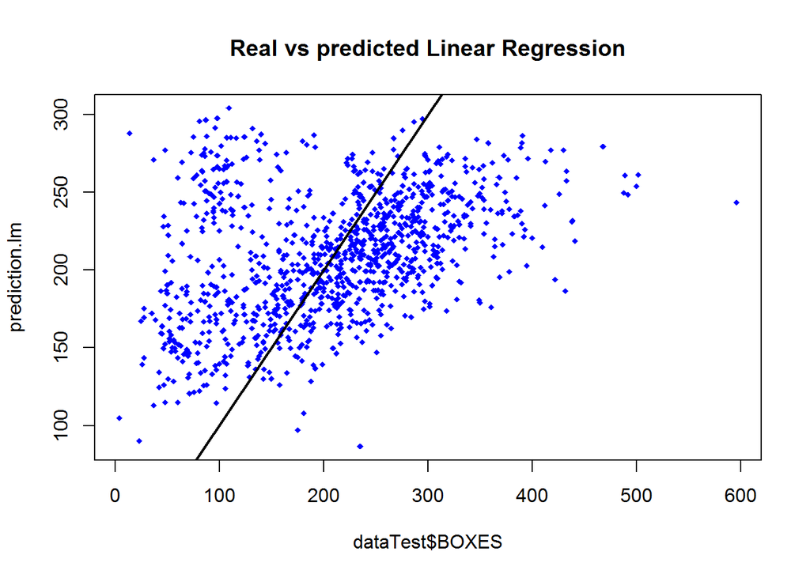

# Create the decision tree model

```r
# model.dt <- rpart(data_formula_boxes, method = "anova", data=dataTrain)
# prediction.dt <- predict(model.dt, newdata = dataTest)
# rmse.dt <- sqrt(mean((dataTest$BOXES-prediction.dt)^2))
# rmse.dt
# plot(dataTest$BOXES,prediction.dt,col='blue',main='Real vs predicted Decision Tree',pch=18, cex=0.7)
# abline(0,1,lwd=2)
```

# Create the random forest model

```r
# dataTrain_fac <- dataTrain %>% mutate_if(is.character, as.factor)
# dataTest_fac <- dataTest %>% mutate_if(is.character, as.factor)
# model.rf <- randomForest(data_formula_boxes, data = dataTrain_fac)
# prediction.rf <- predict(model.rf, newdata = dataTest_fac)
# rmse.rf <- sqrt(mean((dataTest_fac$BOXES-prediction.rf)^2))
# rmse.rf
# plot(dataTest$BOXES,prediction.rf,col='blue',main='Real vs predicted Random Forest',pch=18, cex=0.7)
# abline(0,1,lwd=2)
```

# Create the neural net mode

```r
# library('neuralnet')
#
# maxs <- apply(dataTrain, 2, max)
# mins <- apply(dataTrain, 2, min)
# scaled_train <- as.data.frame(scale(dataTrain, center = mins, scale = maxs - mins))
# scaled_test <- as.data.frame(scale(dataTest, center = mins, scale = maxs - mins))
# n <- names(scaled_train)
# f <- as.formula(paste("BOXES ~", paste(n[!n %in% "BOXES"], collapse = " + ")))
#
# nn <- neuralnet(f,data=scaled_train,hidden=c(8,4),linear.output=F)
# pr.nn <- compute(nn,scaled_test[,0:11])
# pr.nn_ <- pr.nn$net.result*(max(data$BOXES)-min(data$BOXES))+min(data$BOXES)
# test.r <- (scaled_test$BOXES)*(max(data$BOXES)-min(data$BOXES))+min(data$BOXES)
# rmse.nn <- sqrt(mean((dataTest$BOXES-pr.nn_)^2))
# rmse.nn
#
#  plot(dataTest$BOXES,pr.nn_,col='blue',main='Real vs predicted Neural Net',pch=18, cex=0.7)
#  abline(0,1,lwd=2)
```

# Create the boosted random forest model

```r
# tic()
# model.xgb <- xgb.train(data=xgTrain_box, objective='reg:linear', eval_metric='rmse', booster='gbtree', watchlist = list(train=xgTrain_box, validate=xgVal_box),
#                   early_stopping_rounds=100, nrounds = 100000, num_parallel_tree=20, print_every_n = 20, nthread=8,eta = .1, max_depth = 7)
# toc()
# dataTest.xgb <- build.x(data_formula_boxes, data=dataTest, contrasts = FALSE, sparse = TRUE)
#
# prediction.xgb <- predict(model.xgb, newdata = dataTest.xgb)
# plot(dataTest$BOXES,prediction.xgb,col='blue',main='Real vs predicted Boosted Forest',pch=18, cex=0.7)
#  abline(0,1,lwd=2)
```